# Submitted data error checks

# 0. Instructions for submitters

Submitters should use this file to check for problems with submitted data. Each of these html files contains a summary of the data from a single submitted spreadsheet file. The html name is based on the name of the submitted file. Use the details below to check:

- Institute abbreviation, submitter and contributor names
- The plot location(s), using the map zoom and pan features if needed
- For problems in the first sections; “OK” means there are no problems in a particular section, “warning” is something that should be checked (but might be OK), “error” is a problem that needs to be addressed
- For numeric values outside the expected range in the “Value checks” section
- Variables with missing values–are there any missing that you thought you included?
- Plots of flux, cumulative emission over time, and final cumulative emission for strange patterns, unexpectedly high or low values
- Plots of weather data for appropriate differences between plots and expected diurnal or other patterns
- Plots of manure and application data for correct values

Finally, the numeric summary at the end might provide details that can help in pinpointing problems, but typically does not need to be checked.

# 1. Submitter

| inst.abbrev | submitter | version | date |
| --- | --- | --- | --- |
| AU-BCE | Sommer Sven Gjedde | 1 | 13.06.2022 |

# 2. Contributors

| contributor | institute |
| --- | --- |
| Martin Nørregård Hansen | SEGES, Aarhus, Denmark |
| Sven G. Sommer | Aarhus University, Denmark |

# 3. File and directory names

```
## [1] "../../data-submitted/03/AU"
```

```
## [1] "../../data-submitted/03/AU/ALFAM2_template_6.1 SGS(Rev).xlsx"
```

# 4. Location

[interactive chart not shown]

# 5.Keys and codes

## Codes in Treatments sheet

```
## OK
```

```
## OK
```

## Codes in Plots sheet

```
## OK
```

```
## OK
```

## Codes in Emission sheet

```
## OK
```

```
## OK
```

## Code merge check (matching project, experiment, field, plot, treatment)

```
## OK
```

```
## OK
```

```
## OK
```

```
## OK
```

```
## OK
```

# 6. Publication info

## Check for missing codes

```
## [1] "Missing pub codes in Publications sheet."
```

```
## [1] "Some pub codes missing in Experiments sheet."
```

## Complete citations given

```
## OK
```

```
## OK
```

# 7. Emission sheet

## Duplicated intervals

```
## OK
```

## Missing incorporation time

```
## OK
```

## Delay after application

```
## bta (cum. time since application began) is not available.
```

## Missing or double interval number

```
## OK
## OK
## OK
## OK
```

## Missing time between intervals

```
## [1] "No start or end times provided, so cannot check for missing time."
## [1] "No start or end times provided, so cannot check for missing time."
## [1] "No start or end times provided, so cannot check for missing time."
## [1] "No start or end times provided, so cannot check for missing time."
```

## Measurement method and units

Measurement technique:

| Method | Frequency |
| --- | --- |
| ZINST | 24 |

Measurement technique classification:

| Classification | Frequency |
| --- | --- |
| micro met | 24 |

Emission units and conversion factors.

| Original unit | Conversion factor applied | Final unit |
| --- | --- | --- |
| kg N/ha-hr | 1 | kg N/ha-hr |

# 7. Value checks

Check to see if submitted values are within a reasonable range.

## Weather

```
## wind : OK
## rain.rate : OK
## air.temp : OK
## soil.temp : No values to check.
## soil.temp.surf : No values to check.
## air.temp.z : OK
## wind.z : OK
```

## Manure and application

```
## man.stor : No values to check.
## man.dm : Some values out of range
## [1] 31.6 37.3
## man.vs : No values to check.
## man.tkn : OK
## man.tan : OK
## man.tic : No values to check.
## man.ua : No values to check.
## man.vfa : No values to check.
## man.ph : OK
## app.rate : OK
## crop.z : OK
```

## Emission

```
## j.NH3 : OK
## e.int : OK
## e.rel : OK
```

# 8. Missing values

Check for missing values.

## All variables

```
## Some values missing:
## Table below has number of missing observations by variable:
##           silt     soil.water   soil.water.v     soil.moist        soil.ph
##             24             24             24             24             24
##      soil.dens       man.trt2       man.trt3       man.stor         man.vs
##             24             24             24             24             24
##        man.tic         man.ua        man.vfa    time.incorp       dist.inj
##             24             24             24              6             24
##       furrow.z       furrow.w            lai     notes.plot        t.start
##              6             24             24             18             24
##          t.end          bg.dl         bg.val        bg.unit        pH.surf
##             24             24             24             24             24
##      soil.temp    soil.temp.z soil.temp.surf            rad            MOL
##             24             24             24             24             24
##          ustar             rl       air.pres  air.pres.unit             rh
##             24             24             24             24             24
##      notes.int   t.start.orig     t.end.orig        dt.calc        dt.diff
##             23             24             24             24             24
##            cta            bta       pub.info     soil.type2         exper2
##             24             24             24             24             24
##           rep2     date.start
##             24             24
```

## Application method and measurement method

```
## OK
```

```
## OK
```

# 9. Plots

## Calculated cumulative emission

Cumulative emission. Missing values imputed (linear interpolation).

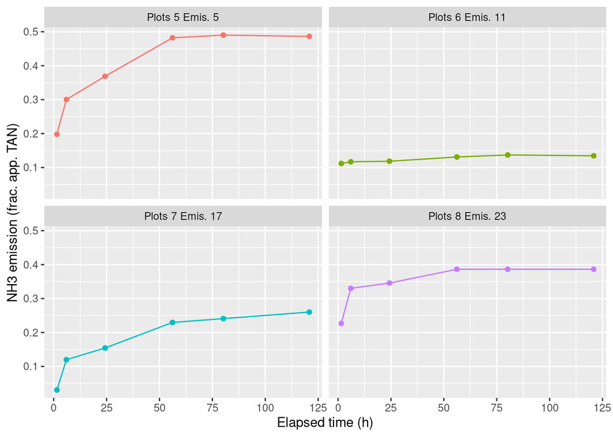

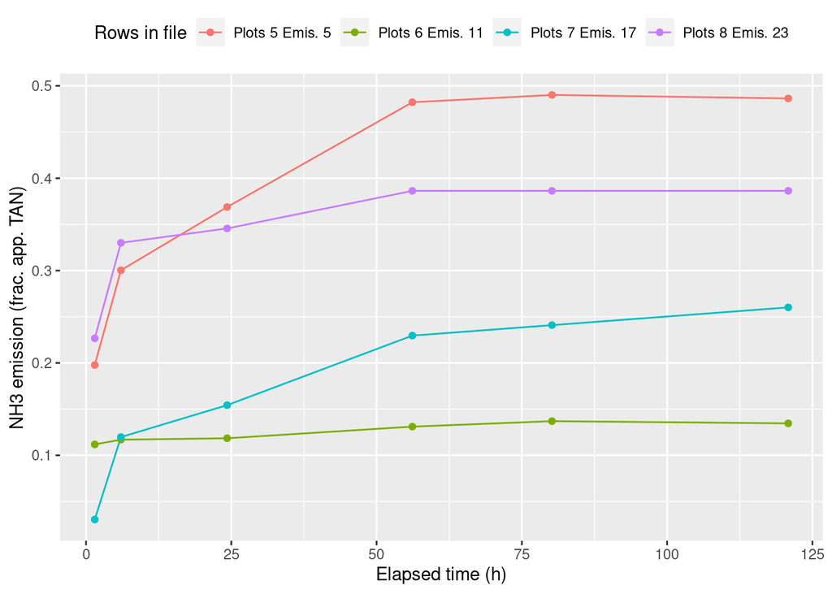

## Final cumulative emission

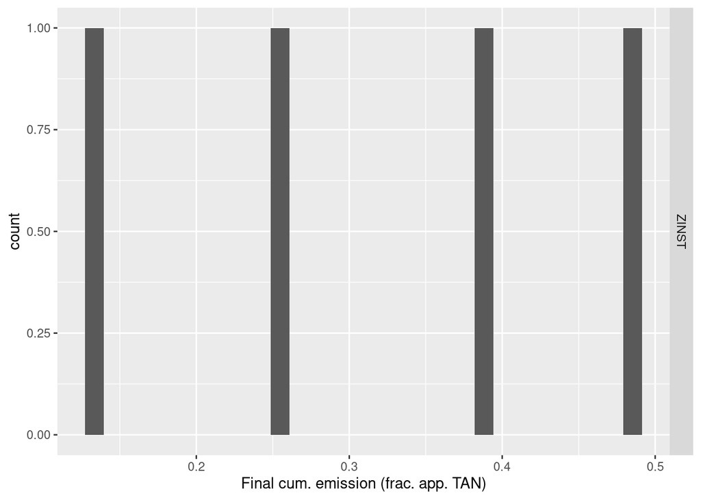

## Relative versus absolute emission

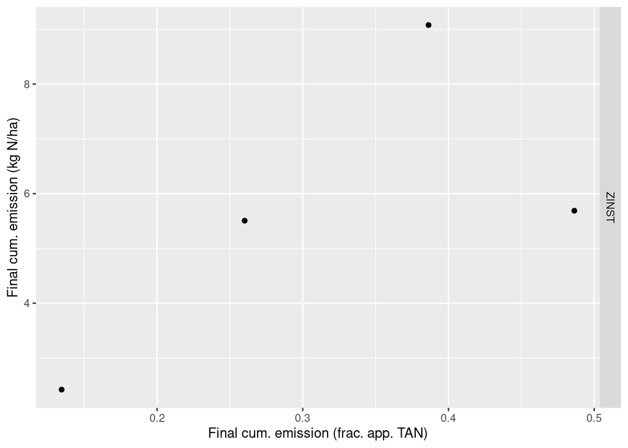

## Flux

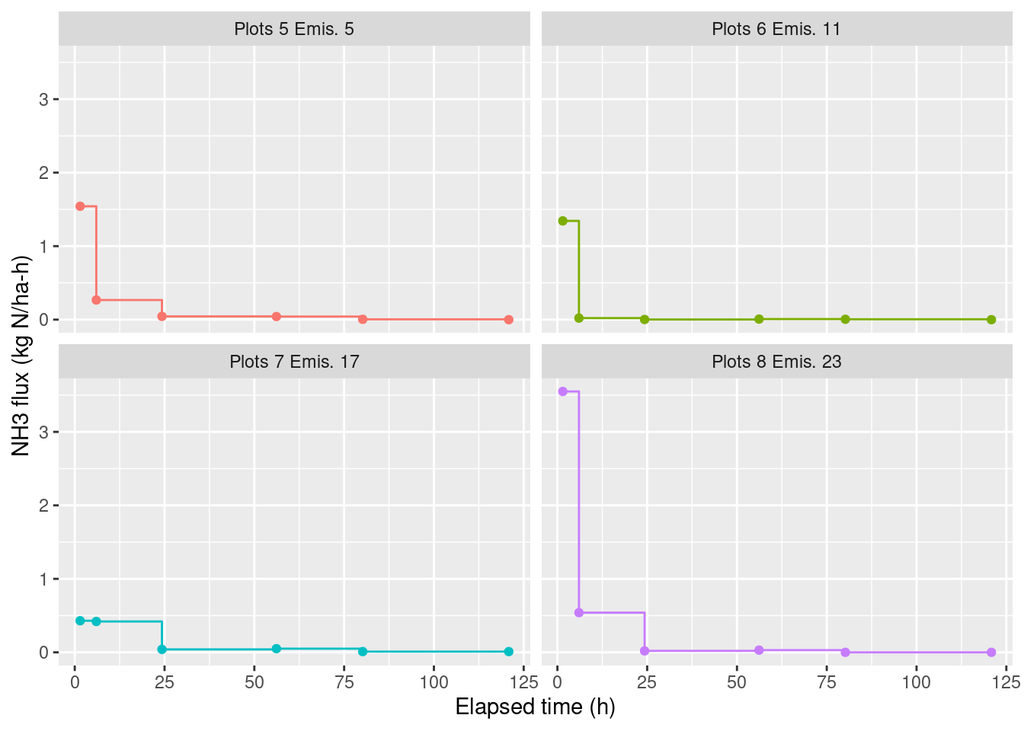

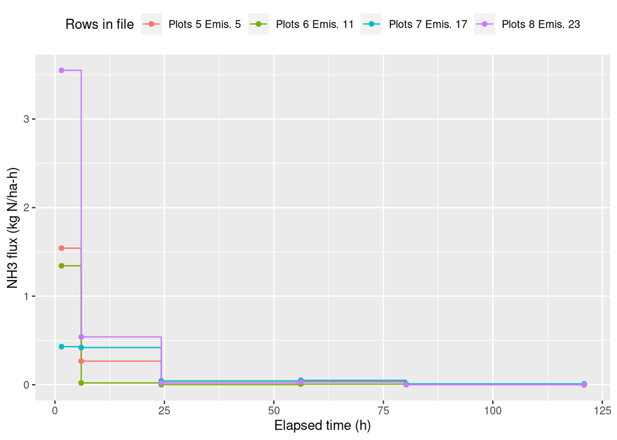

## Weather data

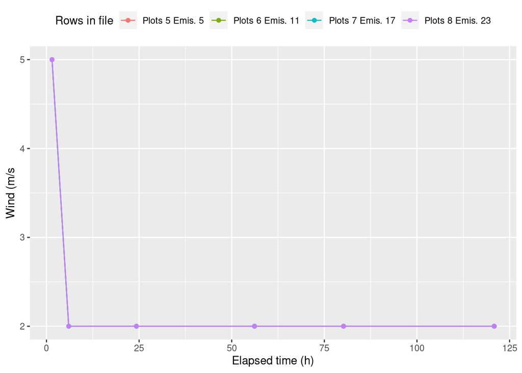

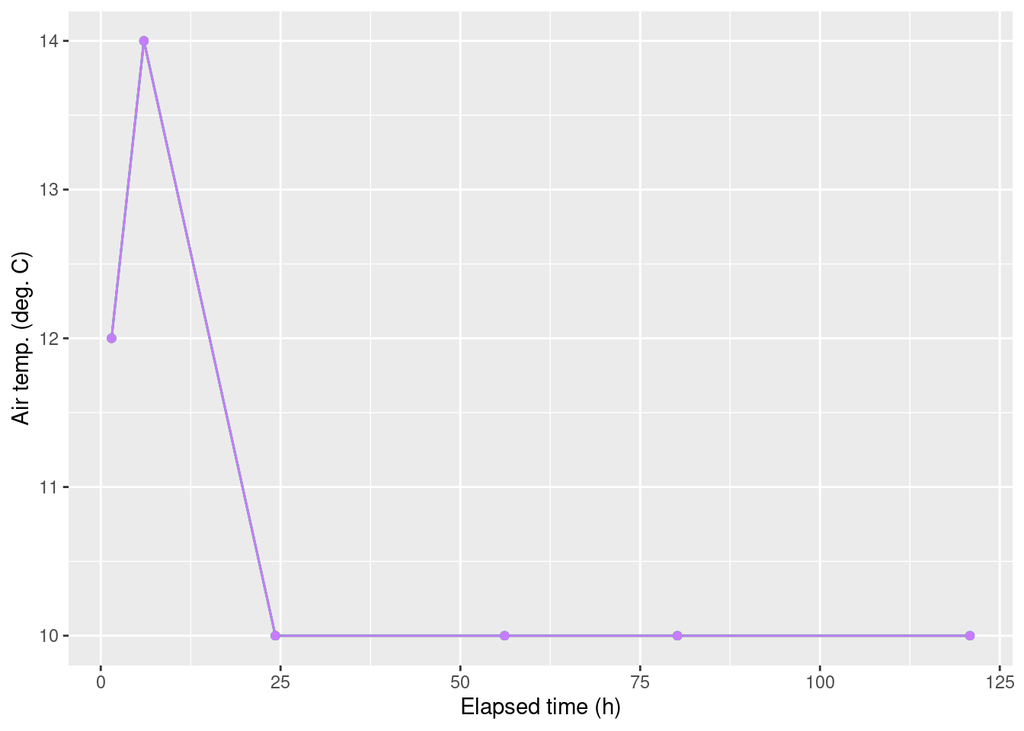

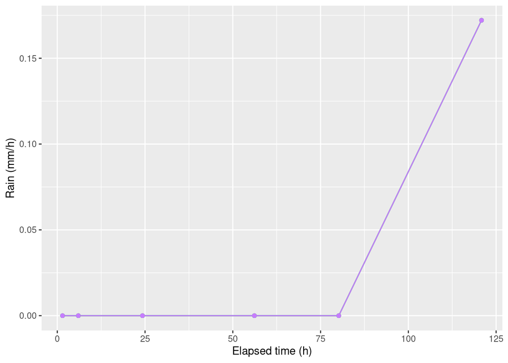

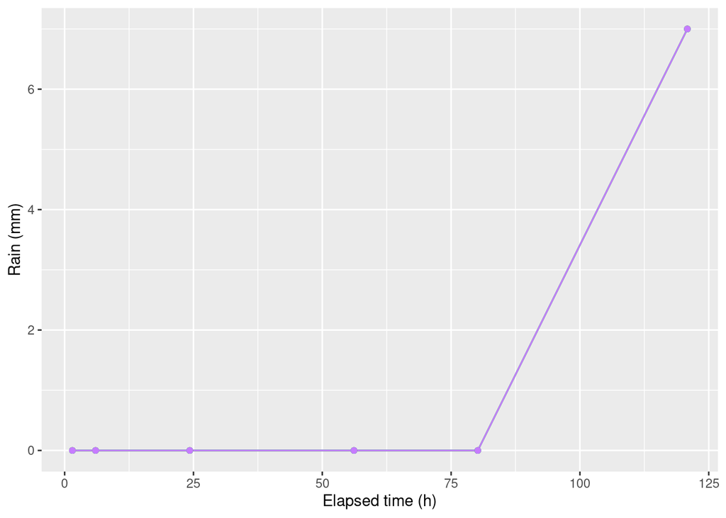

## Manure and application

| institute | proj | exper | field | plot | man.dm | man.ph | man.tan | app.rate | tan.app |
| --- | --- | --- | --- | --- | --- | --- | --- | --- | --- |
| AU-BCE | 1 | 1 | 1 | 1 | 37.3 | 8.6 | 0.86 | 13.6 | 11.696 |
| AU-BCE | 1 | 1 | 1 | 2 | 32.8 | 8.8 | 0.99 | 18.2 | 18.018 |
| AU-BCE | 1 | 1 | 1 | 3 | 31.6 | 8.6 | 1.08 | 19.6 | 21.168 |
| AU-BCE | 1 | 1 | 1 | 4 | 33.8 | 8.7 | 1.27 | 18.5 | 23.495 |

# 10. `dfsumm` summary

```
##
##  24 rows and 135 columns
##  24 unique rows
##                                                                                                                                                                                 cpmid
## Class                                                                                                                                                                       character
## Minimum            D:1.I:AU-BCE.Pr:1.F:../../data-submitted/03/AU/ALFAM2_template_6.1 SGS(Rev).xlsx.E:1.F:1.P:1.T:1.R:1.R2:.T:2004-04-22 09:00:00.M:ZINSTLeuning passive flux sampler
## Maximum            D:1.I:AU-BCE.Pr:1.F:../../data-submitted/03/AU/ALFAM2_template_6.1 SGS(Rev).xlsx.E:1.F:1.P:4.T:4.R:1.R2:.T:2004-04-22 10:30:00.M:ZINSTLeuning passive flux sampler
## Mean                                                                                                                                                                             <NA>
## Unique (excld. NA)                                                                                                                                                                  4
## Missing values                                                                                                                                                                      0
## Sorted                                                                                                                                                                           TRUE
##
##                       pub.id      proj     exper     field    plot     rep
## Class              character character character character numeric numeric
## Minimum                    1         1         1         1       1       1
## Maximum                    1         1         1         1       4       1
## Mean                    <NA>      <NA>      <NA>      <NA>     2.5       1
## Unique (excld. NA)         1         1         1         1       4       1
## Missing values             0         0         0         0       0       0
## Sorted                  TRUE      TRUE      TRUE      TRUE    TRUE    TRUE
##
##                      treat meas.tech                meas.tech.det plot.area
## Class              numeric character                    character   numeric
## Minimum                  1     ZINST Leuning passive flux sampler      1260
## Maximum                  4     ZINST Leuning passive flux sampler      1260
## Mean                   2.5      <NA>                         <NA>      1260
## Unique (excld. NA)       4         1                            1         1
## Missing values           0         0                            0         0
## Sorted                TRUE      TRUE                         TRUE      TRUE
##
##                        lat    long   country      topo    clay    silt    sand
## Class              numeric numeric character character numeric logical numeric
## Minimum               55.9    10.1        DK      Flat    13.1    <NA>    81.7
## Maximum               55.9    10.1        DK      Flat    13.1    <NA>    81.7
## Mean                  55.9    10.1      <NA>      <NA>    13.1    <NA>    81.7
## Unique (excld. NA)       1       1         1         1       1       0       1
## Missing values           0       0         0         0       0      24       0
## Sorted                TRUE    TRUE      TRUE      TRUE    TRUE    <NA>    TRUE
##
##                         oc soil.type soil.water soil.water.v soil.moist soil.ph
```

[output cut: 470 more lines]

```
## Maximum                Shallow       <NA>            23        8
## Mean                      <NA>       <NA>            14      6.5
## Unique (excld. NA)           3          0             4        4
## Missing values               0         24             0        0
## Sorted                   FALSE       <NA>          TRUE     TRUE
##
##                          first.rows
## Class                        factor
## Minimum             Plots 5 Emis. 5
## Maximum            Plots 8 Emis. 23
## Mean               Plots 6 Emis. 11
## Unique (excld. NA)                4
## Missing values                    0
## Sorted                         TRUE
##
```